# Factors Affecting Online Education System Performance

## Investigation Overview

In this investigation, I wanted to look at the factors that had direct effect on the `Online education system based on the satisfactory level of the learners`. Some of the features that were considered closely are:

- Internet facility in your locality
- Your interaction in online mode
- Clearing doubts with faculties in online mode
- Have separate room for studying?
- Are you involved in any sports
- Do elderly people monitor you?
- Home Location
- Study time (Hours)
- Online performance

## Dataset Overview

This dataset aims to analyze the impact of online education by checking out the satisfactory level of the learners with respect to certain features including internet facility, study time (Hours), gender, online performance and other features. The dataset can be found here: https://www.kaggle.com/datasets/sujaradha/online-education-system-review.

### Distribution of Satifaction level in Online Education

A closer look at our variable of interest (satisfactory level) it can be observed that more than 50% of the participants satisfactory level was average. This report will proceed to share some insight of the posile cause

```
Average    52.371733
Good       24.298161
Bad        23.330106
Name: Satifaction level in O.E, dtype: float64
```

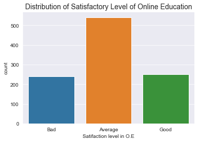

### Home Location Distribution

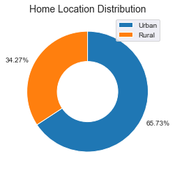

### Plot of Online performance versus Satisfaction level in online education

From the violinplot below we can observe that the feedback on satisfaction level is subjective to the individuals involved, while the average score from the satisfaction level Bad is 60%, we have that for average as 70% and Good as 80%. Whereas they were individuals withh 100% in all satisfaction.

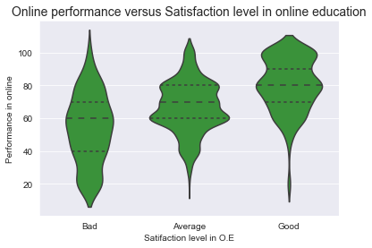

### Plot of Internet facility, Online mode interaction & Clearing doubts with faculties against Satisfaction level

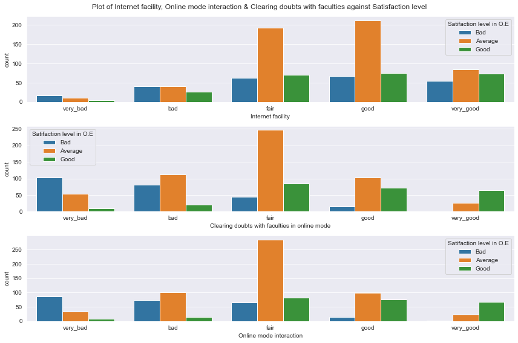

### Correlation between Satisfaction level in Online Education, Online performance and those monitored by elderly people

- The result of the correlation plot shows a level of increase aove the 60% online performance score for students who had elderly people monitor them (we could liken that to mentor or offline instructors)

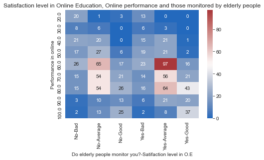

### Correlation between Satisfaction level in Online Education, Online performance and those that have separate room for studying

- The result of the correlation plot shows a level of increase aove the 60% online performance score for students who had separate room for studying.

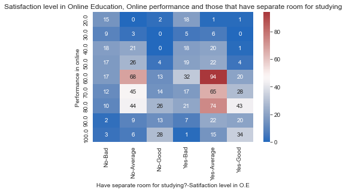

### Correlation between Satisfaction level in Online Education, Online performance and those that are involved in any sports

- The result of the correlation plot shows a level of increase aove the 60% online performance score for students who were not involved in any sports with focus on the `average` and `good` satisfaction levels

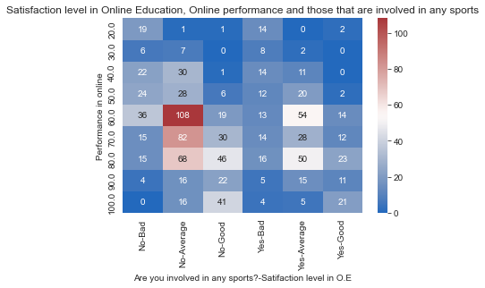

### Plot of Online performance against Satifaction level in Online Education for each Gender

Despite the distribution of male gender being higher than the female, the chart below shows that the female gender performed better across all satisfactory level also.

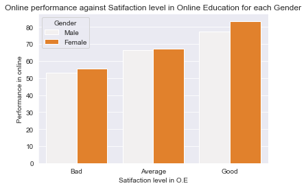